# Techniki wizualizacji danych - praca domowa nr 5

Marceli Korbin

6 grudnia, 2019

## Wstęp

*Jaki błąd najbardziej przeszkadza w odczytywaniu informacji z wykresu?*

W swojej pracy domowej postanowiłem pójść trochę niestandardową drogą. Zamiast bezpośrednio sprawdzać, jakie konkretnie informacje odbierają ankietowani na niedobrych wykresach, zdecydowałem się zbadać u nich, jak dobrze potrafią oni rozpoznać tam błędy; czy są świadomi, w jakim stopniu i w jaki sposób odbiór informacji mógł być u nich zaburzony. Zaznajomiwszy się z rodzajami błędów, których należy unikać w wizualizacji danych, wybrałem 5 z nich, a następnie przyporządkowałem do nich po dwie pary złożone ze starego i nowego wykresu - łącznie 10 par. Pary te zestawiłem z kolei za pomocą wykresów swoich znajomych z pracy domowej nr 3 (folder *TYDZIEN4*) i ich oryginalnych, wadliwych wersji.

Sporządziłem potem [ankietę](https://forms.gle/6Xbpta7x7Nh2cNBb6), w której umieściłem wszystkie pary i do każdej dodałem dwa polecenia do wykonania:

- ocenić wykresy po ich obejrzeniu w skali od 1 do 6,
- wskazać, czym różnił się lepiej oceniony przez ankietowanego wykres.

Ankieta została wypełniona przez 15 osób, wśród których byli moi znajomi zarówno z liceum, jak i z grupy dziekańskiej na PW. Ankietowani są obu płci, ale w podobnym wieku z zakresu 20-21 lat. W tym raporcie przedstawię wyniki ankiety: który wykres był średnio lepiej oceniany i czy w komentarzach były wytykane popełnione/poprawione błędy.

W każdym z wykresów podsumowujących “A” oznacza wyższą ocenę dla wykresu starego, “remis” - tę samą dla obu, a “B” - wyższą dla nowego. Pod każdym wykresem są spisane tłumaczenia, czym różnił się nowy wykres, autorstwa ankietowanych, którzy ocenili go lepiej.

### Problem 1: słupki niezaczynające się od zera

#### Para 1: dług sektora instytucji rządowych i samorządowych do PKB

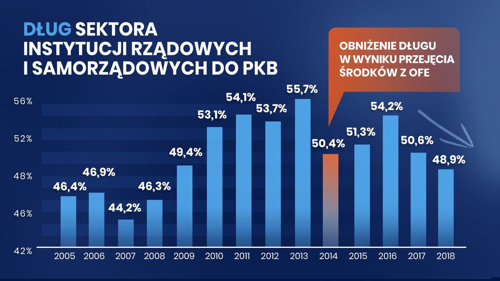

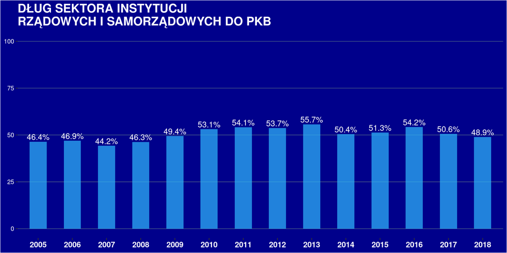

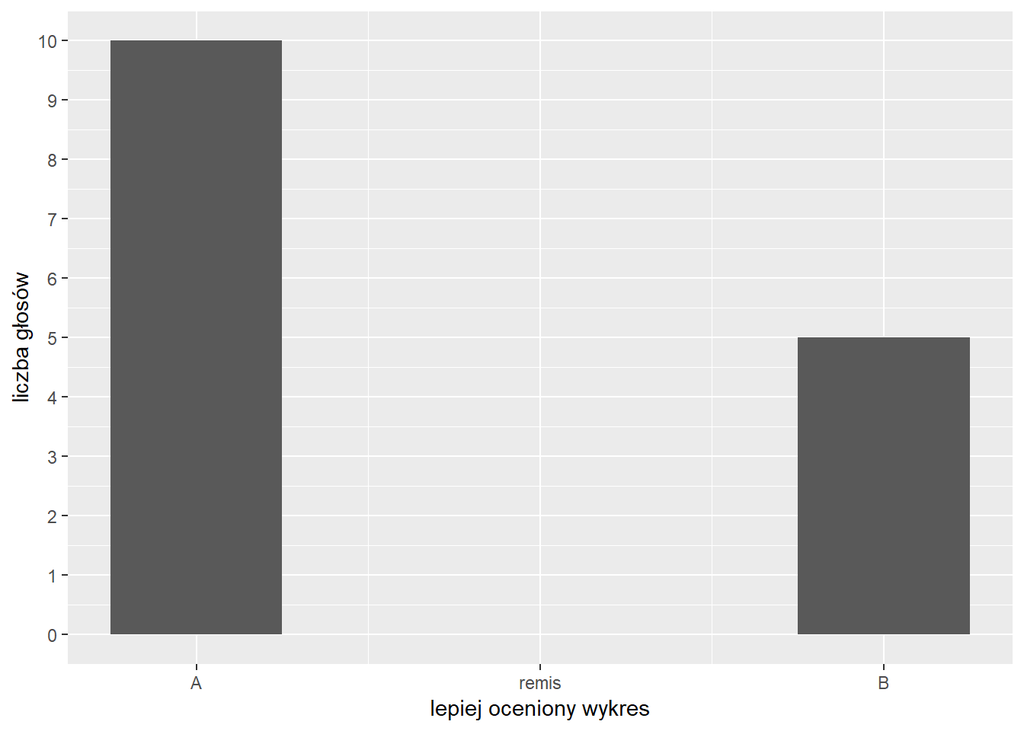

| x |
| --- |
| Mniej manipulacji, np przez kolor itp |
| Nie zawierał próby manipulacji (celowe wyskalowanie w celu pompowania małych różnic) |
| Pierwszy ma ubcięta skalę |
| miał skalę od 0 |
| Miał lepszą skalę, ale gorszą estetykę |

Lepiej został oceniony wadliwy wykres - tylko 5 osób zwróciło uwagę na złe wyskalowanie lub manipulację ogółem.

#### Para 2: plon ziarna na tle wzorca pszenicy jakościowej

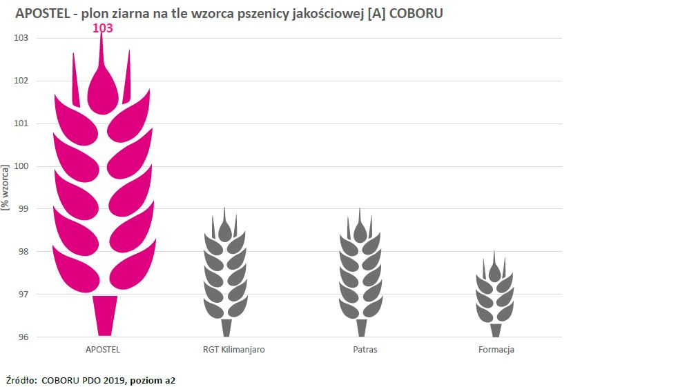

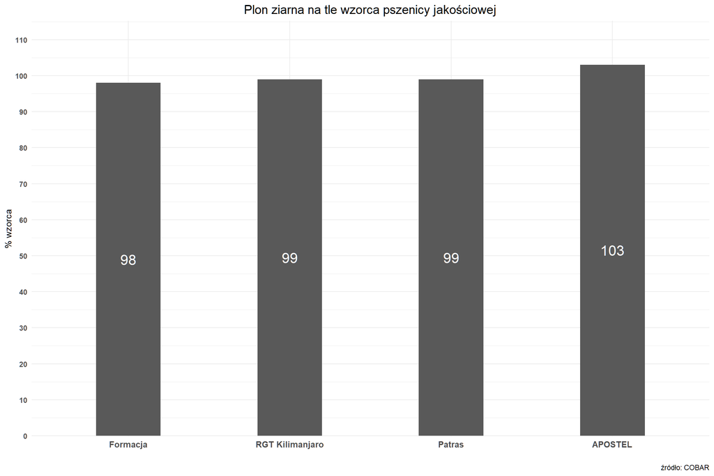

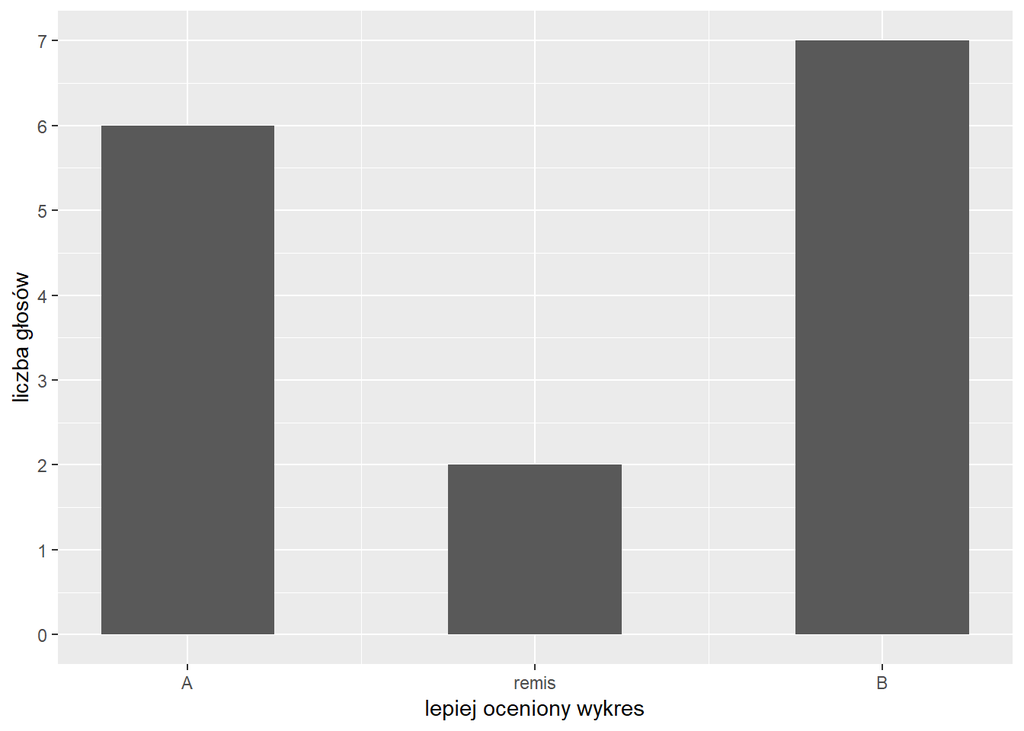

| x |
| --- |
| Lepsze porównanie poszczególnych plonów (mała różnica widoczna na pierwszy rzut oka) |
| Nie wyolbrzymiał małych różnic, brak zbędnej grafiki |
| Jest bardziej precyzyjny i czytelny |
| Dokładniej pokazane wartości |
| Pierwszy ma obcieta skalę |
| skala od 0 |
| Skala y |

### Problem 2: niewłaściwie dobrana geometria

#### Para 3: spadek umieralności dzieci na malarię

[figure not shown]

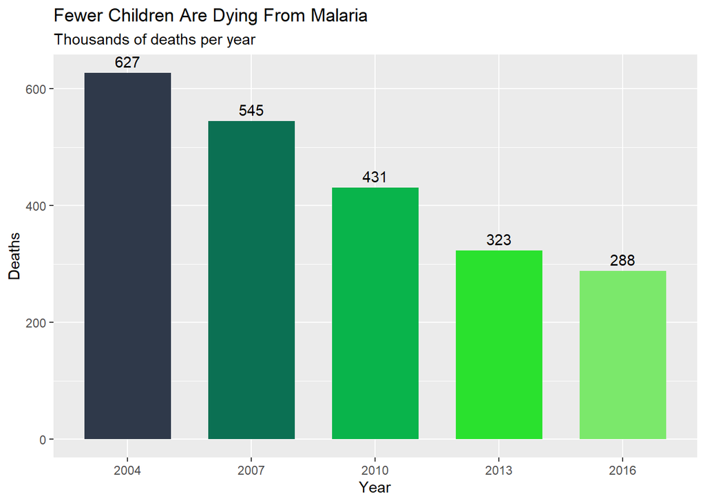

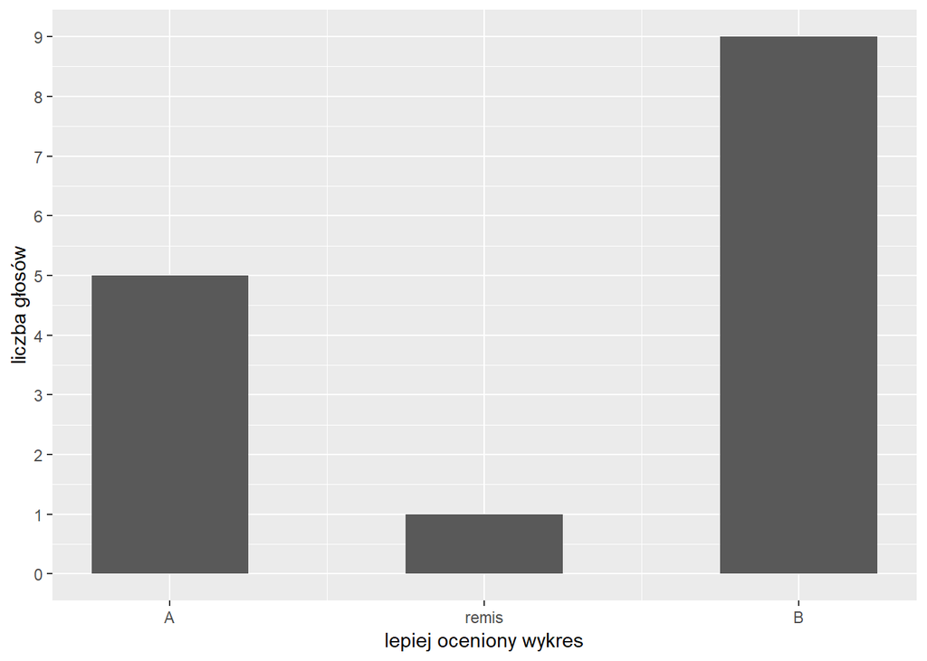

| x |
| --- |
| Jest dużo bardziej czytelny i przejrzysty |
| łatwiej się go czyta, bardziej widać spadek i od razu wiadomo o co chodzi, drugi wykres nie przypomina wykresu, przez co trzeba się przez chwilę zastanowić co właściwie pokazuje |
| Bardziej czytelny |
| Czytelniejszy |
| Oba wykresy są dobre, jednak bardziej przemawiają do mnie wykresy kolumnowe gdzie wartości są przedstawione na jasnym, a nie ciemnym tle. |
| Wartości łatwiejsze do odczytu |
| łatwiej odczytać proporcję |
| Słupki |
| Nie przekłamywał danych |

#### Para 4: liczebność klas społecznych

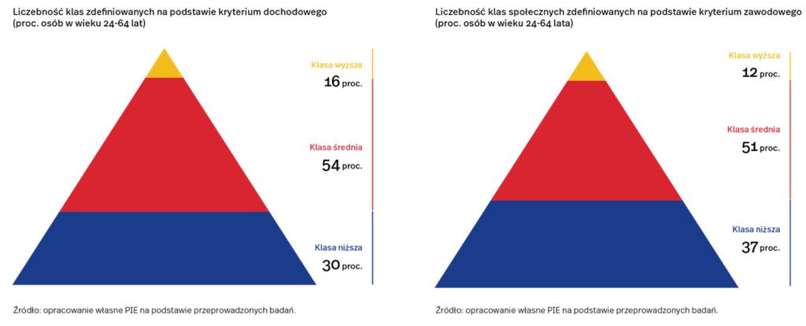

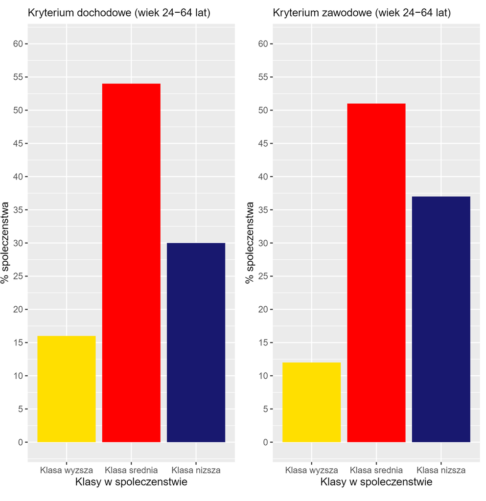

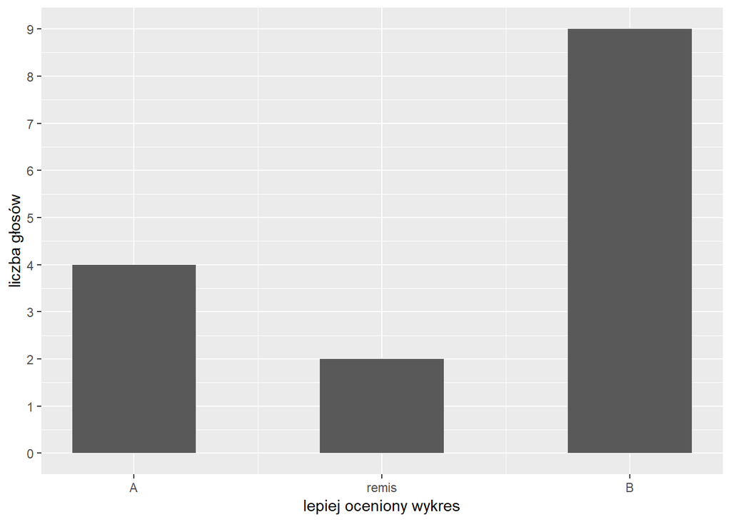

| x |
| --- |
| Bardziej czytelny |
| Bardziej czytelny |
| Piramida wydajr się być strasznie nieproporcjonalna |
| Widać większy kontrast między liczebnością klas niż na pierwszym wykresie. Brakuje jedynie podania dokładnych procentowych wartości liczebności w każdej klasie np. nad odpowiednim słupkiem wykresu. |
| Nie manipuluje |
| O co chodzi w tych piramidach? |
| Łatwiej prównywać dane |
| łatwiej odczytać proporcje |
| Czytelność |

Poprawienie geometrii zostało bardziej docenione przez ankietowanych - po 9 osób wskazuje na większą czytelność poprawionej wizualizacji.

### Problem 3: niezachowane proporcje

#### Para 5: najbogatsze administracje miejskie w Filipinach

[figure not shown]

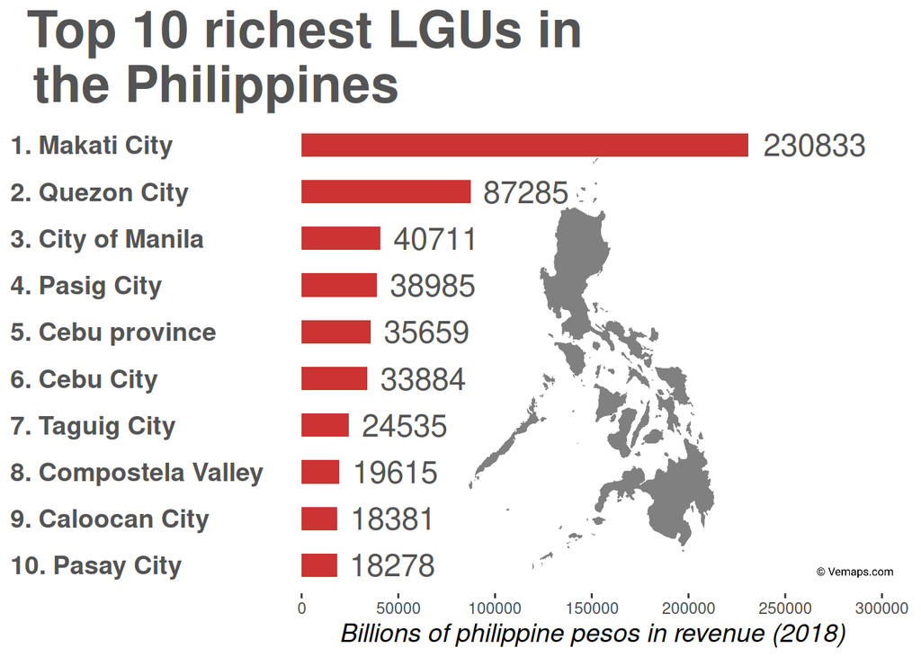

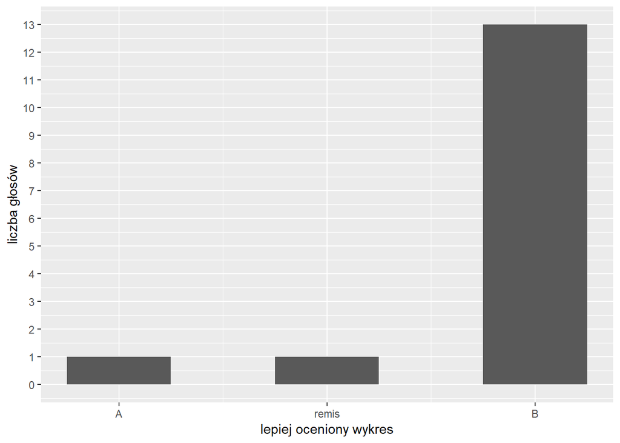

| x |
| --- |
| Lepiej widoczna różnica (proporcja lepiej zachowana) |
| Odzwierciedla różnice, nie zaciera ewidentnych przepaści |
| na drugim wykresie lepiej widać różnicę |
| Lepszy wygląd |
| Lepsza skala i porównanie |
| Nie manipuluje, jest ładniejszy |
| Na gorszym jest niewielka różnica między największymi wartościami |
| 1 ma nieproporcjonalne słupki |
| Czytelnością |
| dobre proporcje |
| skala od 0 |
| Skala |
| Pokazywał realne różnice |

Niezachowane proporcje niewątpliwie są dla odbiorców dużym błędem w wizualizacji danych…

#### Para 6: poparcie dla różnorodności społeczeństwa w USA

[figure not shown]

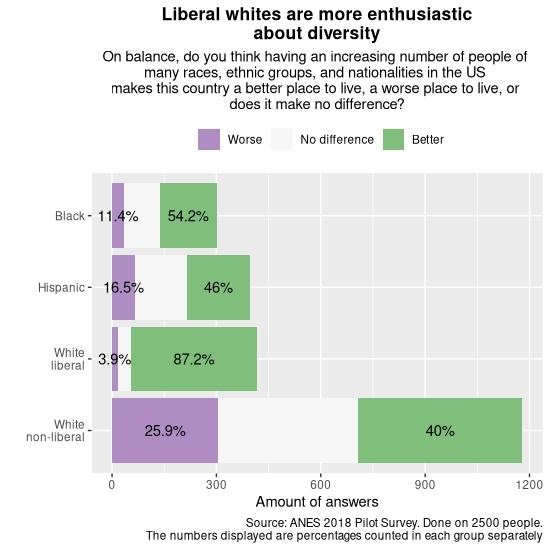

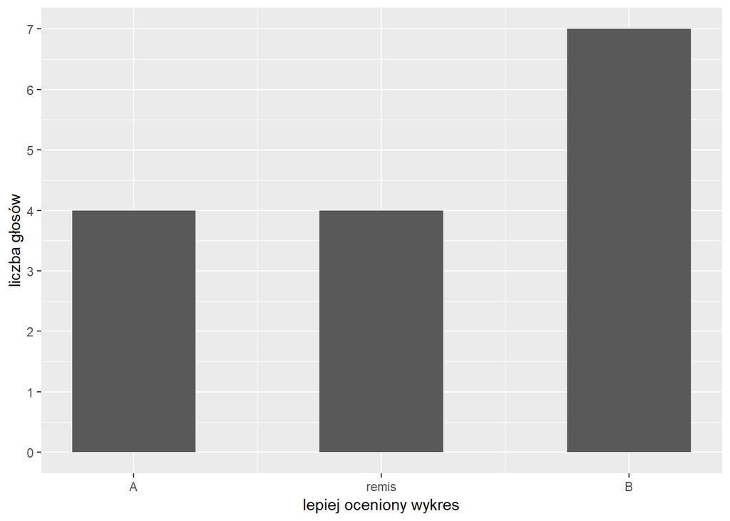

| x |
| --- |
| lepszy wykres nie przekłamuje danych, ale niestety wygląda gorzej |
| Żaden nie jest dobry |
| Przedstawia więcej danych |
| Jest ładny i jednoznaczny |
| Pokazuje skalę |
| kolory |
| dopasowana skala do liczebnosci |

### Problem 4: zwodniczość użycia 3D

#### Para 7: koszty współpracy z mediami gminy Kołobrzeg

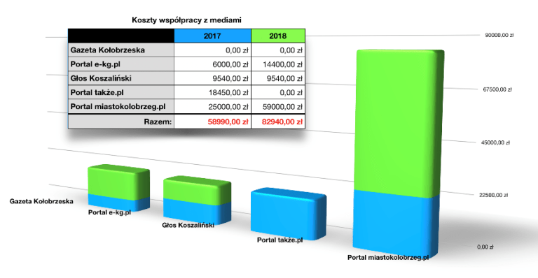

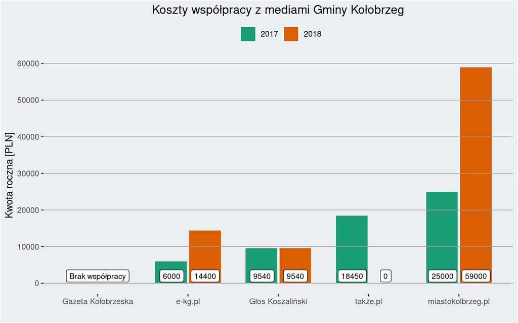

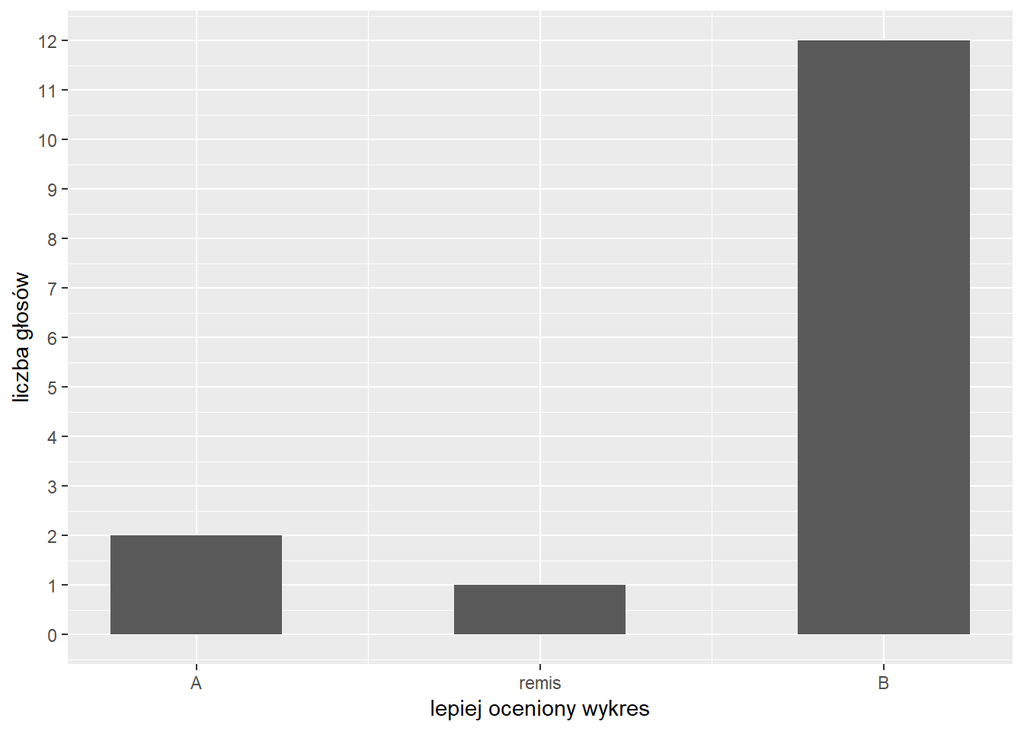

| x |
| --- |
| Bardziej czytelny |
| Czytelny |
| litery na gorszym wykresie są nieczytelne i sprawia wrażenie jakby te koszty z kolejnych lat się w jakiś sposób dodawały, w drugim lepiej widać różnicę między poszczególnymi mediami i latami |
| Efekty 3D naprawdę są użyteczne i sprzyjają czytelności wykresu |
| Zasada KISS |
| Nie ma mylącego 3D |
| Wymiarami |
| Nie jest 3D |
| Czytelnością |
| łatwiej prównać |
| łatwiej odczytać informacje |
| Nie był w 3D |

#### Para 8: wyniki wyborów do parlamentu w powiecie chojnickim

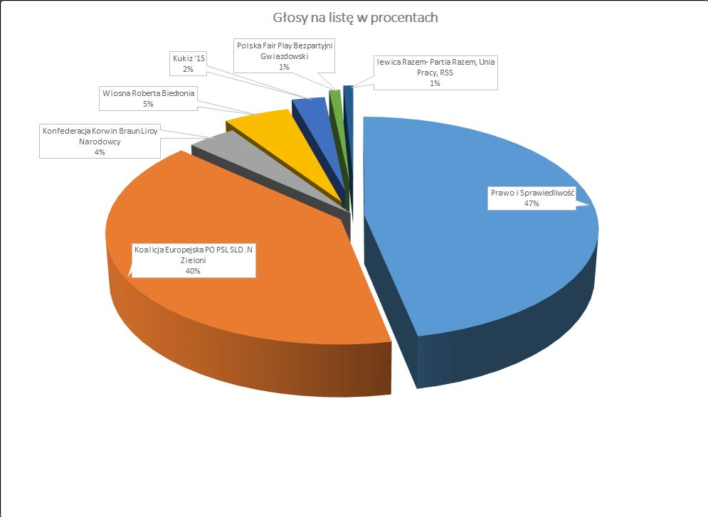

[figure not shown]

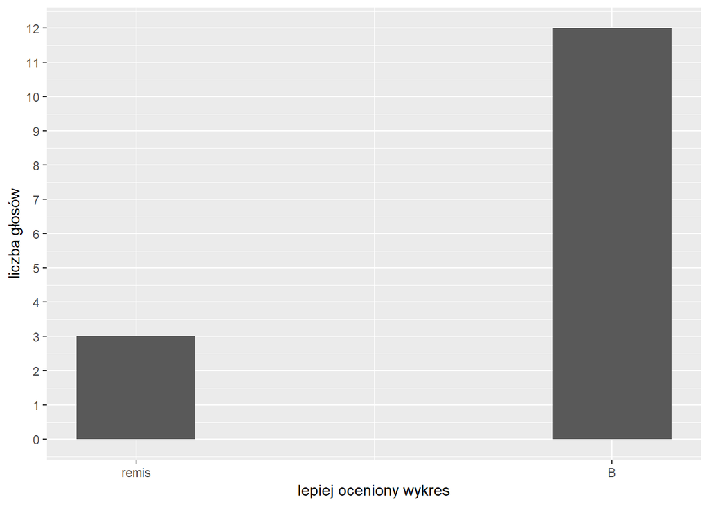

| x |
| --- |
| Bardziej czytelny |
| wszystko ładnie widać, nawet loga |
| Klasyczny model wykresu bardziej pasuje do sytuacji, która opisuje |
| Czytelniejzy |
| Dzięki logom widać wyraźnie na jaką partię głosowano, wykres jest czytelny i ma wyraźną czcionkę o odpowiedniej wielkości. Widać różnice ilości między głosami zdobytymi przez partie. |
| Fuuu! Wykres kołowy |
| Od czego? |
| nie jest 3D kołowy |
| Czytelnością |
| czytelniejszy |
| Słupki |
| Nie był w 3D |

Wykresy 3D ewidentnie nie przekonały ankietowanych aż tak, jak 2D. W obydwu parach ankietowani odpowiedzieli się za czytelnością, a niektórzy wręcz podkreślili sam fakt wycofania trzeciego wymiaru. Stary wykres w parze numer 8 dodatkowo popełnia błąd w postaci kołowości, który zostanie rozpatrzony osobno.

### Problem 5: wykres kołowy

#### Para 9: Amerykanie, którzy próbowali marihuany

[figure not shown]

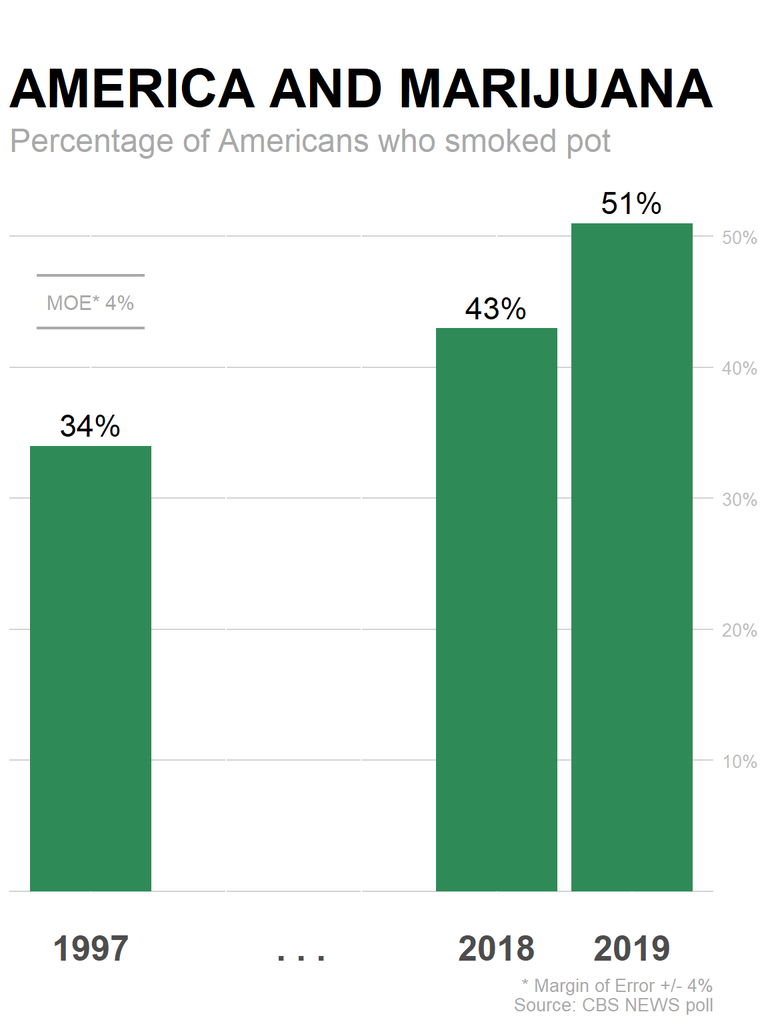

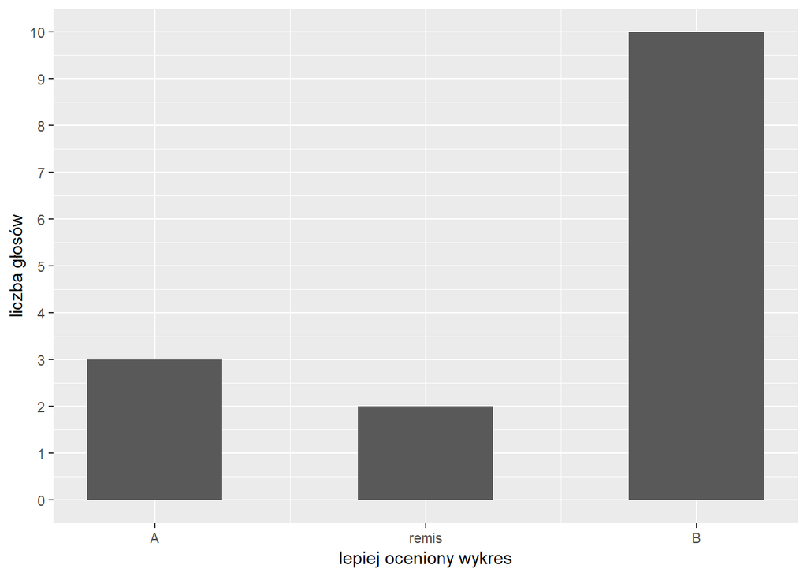

| x |
| --- |
| Bardziej czytelny |
| Gorszy wykres na pierwszy rzut oka sugeruje jakby to całe koło było całością społeczeństwa. Zupełnie nie wiadomo czemu użyto tu kołowego wykresu. Ponadto podpis, że ponad połowa, jest mylący bo ponad … |
| Procenty w kółku powinny się sumować do 100 |
| Wszystko jasne i przejrzyste na pierwszy rzut oka |
| Nie wprowadza w błąd |
| kołowy nie jest do takich danych |
| jest sensowny xD |
| nie wprowadza w błąd |
| Sens danych |
| Pierwszy wykres - wow |

Dziesięć osób lepiej oceniło poprawioną wersję, przy czym niektórzy dodatkowo podkreślili, że wykres nie jest kołowy i nie wprowadza w błąd.

#### Para 10: eksport mięsa drobiowego w I półroczu 2018

[figure not shown]

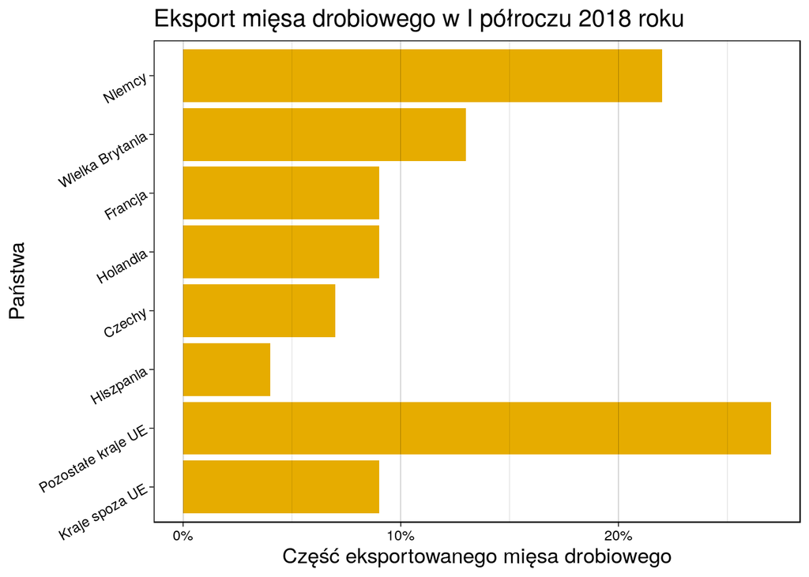

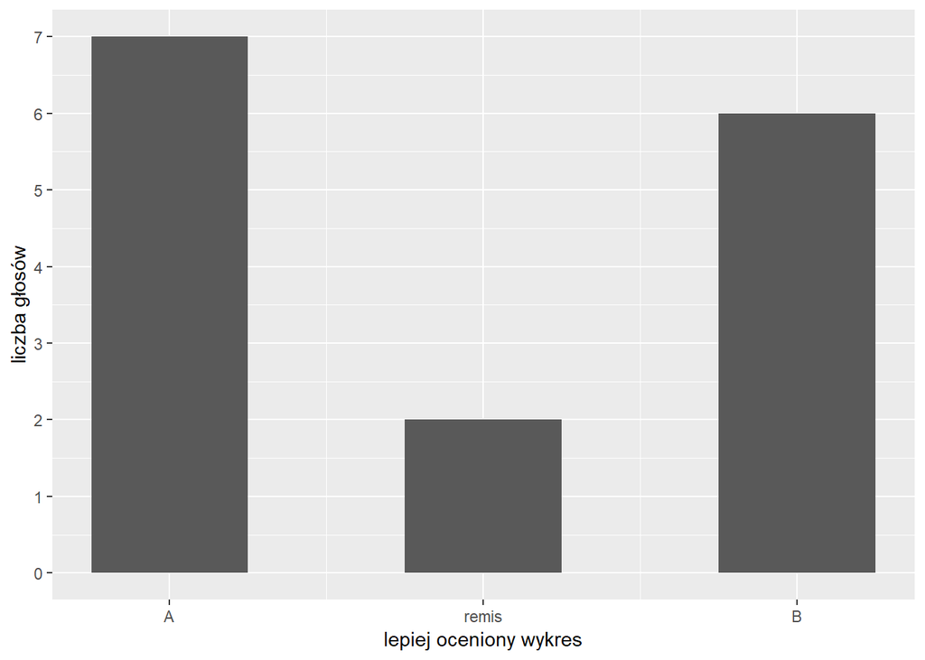

| x |
| --- |
| Widoczna różnica na pierwszy rzut oka, bardziej czytelny |
| Pierwszy jest jakoś dziwnie ułożony, i sugeruje, że to jest część światowego eksportu mięsa, Drugi sugeruje, że to część eksportu mięsa dla danego kraju. Nie wiem która sugestia jest prawdziwa, przekł… |
| Łatwiej zczytać wyniki |
| Łatwo zobaczyć który kraj do jakiego się odnosi |
| łatwiej odczytać proporcje |
| Czytelność, mniej kolorków |